# CFPB Complaint Analysis

### Explore Data

**Complaints by Financial Product (Focus on top 10)**

“Credit Reporting”, “Credit Repair Services”, or “Other Personal Consumer Reports”, followed by “Mortgage”, and “Debt Collection” receive the most complaints.

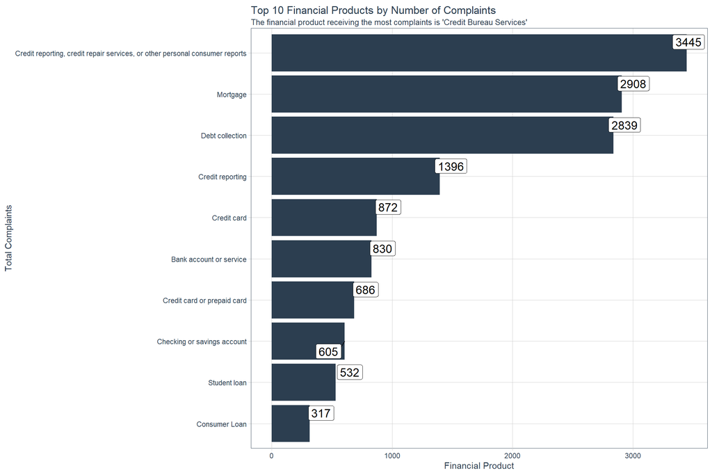

```r
cfpb_sample %>%
    select(financial_product, complaint_id) %>%
    group_by(financial_product) %>%
    summarise(total_complaints = n()) %>%
    ungroup() %>%
    arrange(-total_complaints) %>%
    head(10) %>%
    mutate(financial_product = financial_product %>% as_factor() %>% fct_reorder(total_complaints)) %>%

    ggplot(aes(financial_product, total_complaints)) +
    geom_col(fill = "#2c3e50") +
    ggrepel::geom_label_repel(aes(label = total_complaints), size = 5) +
    theme_tq() +
    labs(title    = "Top 10 Financial Products by Number of Complaints",
         subtitle = "The financial product receiving the most complaints is 'Credit Bureau Services'",
         x        = "Total Complaints",
         y        = "Financial Product") +
    coord_flip()
```

**Complaints by Consumer Issue (Focus on top 10)**

The top issues consumers have with financial products range from “Incorrect information on your report” to “Communication tactics”.

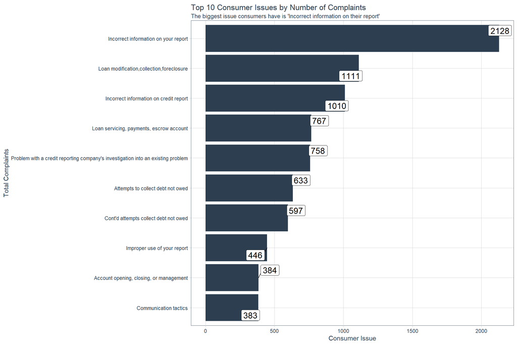

```r
cfpb_sample %>%
    select(consumer_issue, complaint_id) %>%
    group_by(consumer_issue) %>%
    summarise(total_complaints = n()) %>%
    ungroup() %>%
    arrange(-total_complaints) %>%
    head(10) %>%
    mutate(consumer_issue = consumer_issue %>% as_factor() %>% fct_reorder(total_complaints)) %>%

    ggplot(aes(consumer_issue, total_complaints)) +
    geom_col(fill = "#2c3e50") +
    ggrepel::geom_label_repel(aes(label = total_complaints), size = 5) +
    theme_tq() +
    labs(title    = "Top 10 Consumer Issues by Number of Complaints",
         subtitle = "The biggest issue consumers have is 'Incorrect information on their report'",
         x        = "Total Complaints",
         y        = "Consumer Issue") +
    coord_flip()
```

**Consumer Preferences re: Channel to Submit Complaint**

Consumers prefer to submit their complaints throug the web.

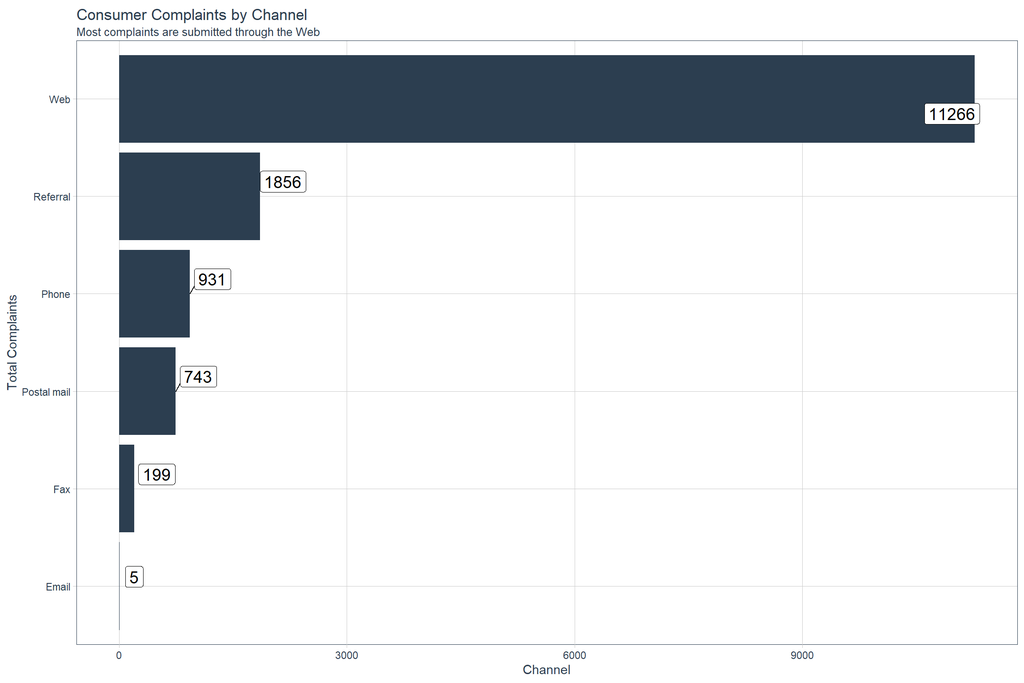

```r
cfpb_sample %>%
    select(complaint_submission_channel, complaint_id) %>%
    group_by(complaint_submission_channel) %>%
    summarise(total_complaints = n()) %>%
    ungroup() %>%
    arrange(-total_complaints) %>%
    mutate(complaint_submission_channel = complaint_submission_channel %>% as_factor() %>% fct_reorder(total_complaints)) %>%

    ggplot(aes(complaint_submission_channel, total_complaints)) +
    geom_col(fill = "#2c3e50") +
    ggrepel::geom_label_repel(aes(label = total_complaints), size = 5) +
    theme_tq() +
    labs(title    = "Consumer Complaints by Channel",
         subtitle = "Most complaints are submitted through the Web",
         x        = "Total Complaints",
         y        = "Channel") +
    coord_flip()
```

**Top Company Responses (Focus on Top 10)**

The most prevalent responses to consumer complaints reported by companies is “Closed with explanation” and “Closed with non-monetary relief”.

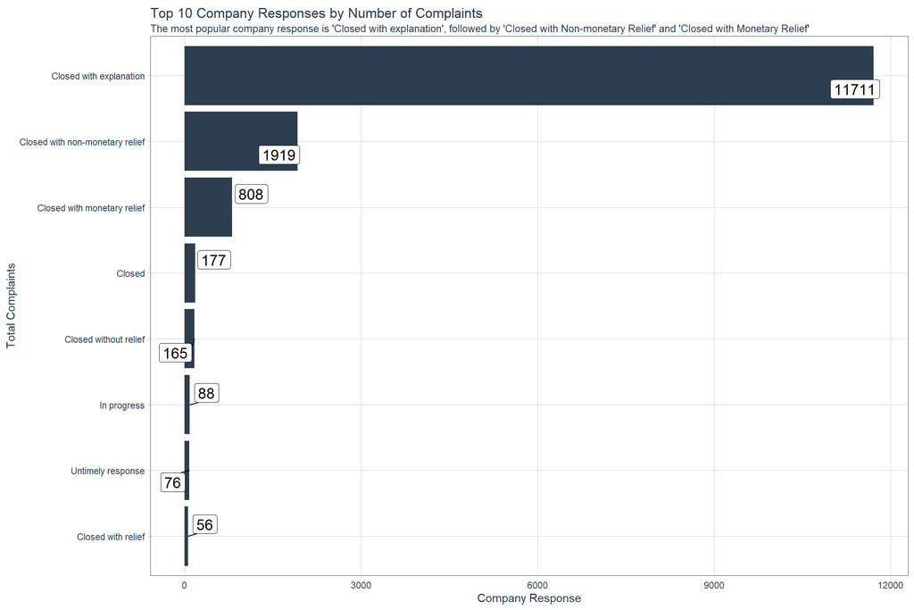

```r
cfpb_sample %>%
    select(company_complaint_response, complaint_id) %>%
    group_by(company_complaint_response) %>%
    summarise(total_complaints = n()) %>%
    ungroup() %>%
    arrange(-total_complaints) %>%
    head(10) %>%
    mutate(company_complaint_response = company_complaint_response %>% as_factor() %>% fct_reorder(total_complaints)) %>%

    ggplot(aes(company_complaint_response, total_complaints)) +
    geom_col(fill = "#2c3e50") +
    ggrepel::geom_label_repel(aes(label = total_complaints), size = 5) +
    theme_tq() +
    labs(title    = "Top 10 Company Responses by Number of Complaints",
         subtitle = "The most popular company response is 'Closed with explanation', followed by 'Closed with Non-monetary Relief' and 'Closed with Monetary Relief'",
         x        = "Total Complaints",
         y        = "Company Response") +
    coord_flip()
```

**Top States for Complaints (Focus on Top 10)**

Most complaints are coming from California, Florida, Texas, New York, and Georgia.

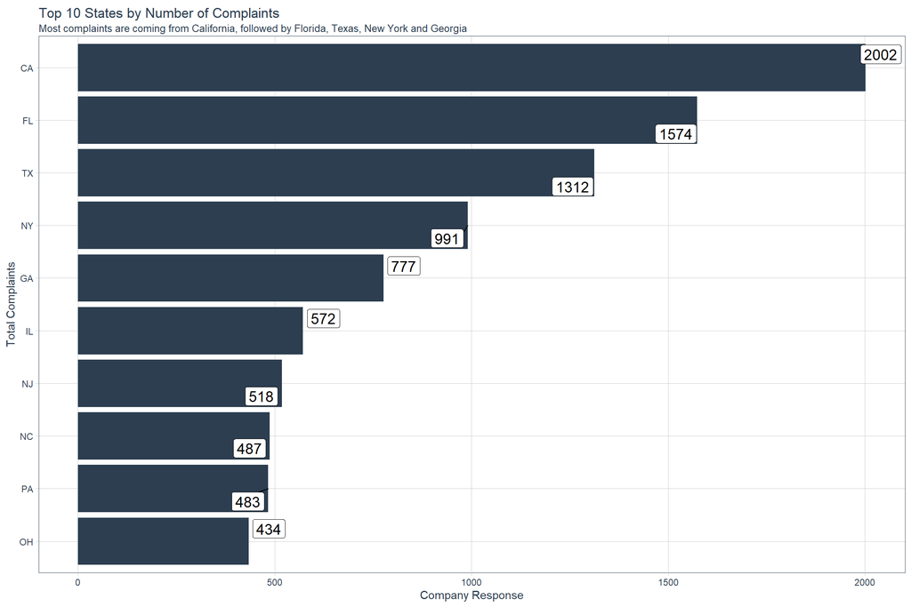

```r
cfpb_sample %>%
    select(consumer_state, complaint_id) %>%
    group_by(consumer_state) %>%
    summarise(total_complaints = n()) %>%
    ungroup() %>%
    arrange(-total_complaints) %>%
    head(10) %>%
    mutate(consumer_state = consumer_state %>% as_factor() %>% fct_reorder(total_complaints)) %>%

    ggplot(aes(consumer_state, total_complaints)) +
    geom_col(fill = "#2c3e50") +
    ggrepel::geom_label_repel(aes(label = total_complaints), size = 5) +
    theme_tq() +
    labs(title    = "Top 10 States by Number of Complaints",
         subtitle = "Most complaints are coming from California, followed by Florida, Texas, New York and Georgia",
         x        = "Total Complaints",
         y        = "Company Response") +
    coord_flip()
```